# Работа про проекту

anonymus

Ноябрь 3, 2019

# Задание 1

**Описание**: нам надо как-то объединить наблюдения в единую таблицу. Пожалуйста, напиши пользовательскую функцию, благодаря которой мы сможем собрать все наши наблюдения воедино. Так как экспедиции являются ежегодными, а данные всегда называются по разному, то функция должна объединять все файлы одного расширения из заданной папки. Суммарно у тебя должно получиться 4177 наблюдений

**Решение**: я вообразил что у меня на компьютере не хватит памяти для данных всех моллюсков - отказался разархивировать файл Data.zip и решил прочитать сразу из него. Вот что вышло.

```r
library(data.table)
library(dplyr)

read_allCsvZip <- function(path_to_zip){
  fread(paste("unzip -p", path_to_zip, sep = " "), header = T) %>%
    filter(.[,1] != colnames(.)[1]) -> data
}

test <- read_allCsvZip("Data.zip")
```

Посмотрим сколько получилось наблюдений и колонок, видим что все хорошо.

```r
test %>% summarise(n_rows = nrow(.), n_columns =  ncol(.))
```

```
##   n_rows n_columns
## 1   4177         9
```

Но реальность говорит о том, что у нас всего 11 файлов, поэтому я написал что-то неоптимальное, написав функцию, которая добавила колонку с фамилией ученого, который виноват собрал данные, чтобы если что потом обвинить наградить его за хорошее заполнение таблиц, в ходе сбора и обработки материала. Однако для этой функции, требуется разархивировать файл.

```r
read_allCsvZip_person <- function(path_to_zip){
  unzip(path_to_zip)
  path <- gsub(path_to_zip, pattern = "\\.zip",replacement = "")
  whole_data <- data.frame()
  researcher <- vector()
  my_files <- list.files(path, pattern=".csv", full.names=TRUE,recursive=FALSE)

  for (file in (1:length(my_files))){
    researcher <- append(researcher,
                         rep(x = gsub(basename(my_files[file]),pattern = "\\.csv",replacement = ""),nrow(read.csv(my_files[file]))))
    whole_data <- rbind(whole_data, read.csv(my_files[file]))
  }

  whole_data$researcher <- as.factor(researcher)

  return(whole_data)
}

data <- read_allCsvZip_person("Data.zip")
```

Посмотрим на данные, только на некоторые колонки (чтобы удостовериться, что ученые добавлены)

```r
data %>% group_by(researcher) %>% slice(1) %>% select(1,3,4,5,10)
```

```
## # A tibble: 11 x 5
## # Groups:   researcher [11]
##    Rings Length Diameter Height researcher
##    <chr> <chr>     <dbl>  <dbl> <fct>
##  1 18    0.575     0.45   0.17  Chandramowlishwaran
##  2 7     0.4       0.305  0.1   Ivanov
##  3 10    0.62      0.48   0.17  Karasev
##  4 23    0.515     0.4    0.16  Koslov
##  5 10    0.63      0.485  0.165 Kyrochkina
##  6 11    0.445     0.345  0.13  Nosova
##  7 5     0.205     0.15   0.055 Osipenko
##  8 6     0.31      0.22   0.085 Petrov
##  9 9     0.505     0.4    0.165 Popova
## 10 9     0.57      0.45   0.14  Sidorov
## 11 10    0.69      0.505  0.2   Vasechkin
```

# Задание 2

**Описание**: посмотри, действительно ли все данные корректны? Если найдешь, что что-то не так, то исправь это, пожалуйста. Только объясни нам, почему ты воспользовался именно этим подходом. Может быть у него есть альтернативы?

**Решение**: Сначала нужно взглянуть на данные, посмотреть что они из себя представляют.

```r
str(data)
```

```
## 'data.frame':    4177 obs. of  10 variables:
##  $ Rings                                 : chr  "18" "14" "8" "12" ...
##  $ Sex..1...male..2...female..3...uvenil.: chr  "2" "3" "1" "1" ...
##  $ Length                                : chr  "0.575" "0.385" "0.475" "0.665" ...
##  $ Diameter                              : num  0.45 0.305 0.37 0.525 0.12 0.16 0.565 0.43 0.175 0.3 ...
##  $ Height                                : num  0.17 0.095 0.125 0.18 0.075 0.05 0.2 0.15 0.055 0.115 ...
##  $ Whole_weight                          : num  1.048 0.252 0.649 1.429 0.117 ...
##  $ Shucked_weight                        : num  0.3775 0.0915 0.347 0.6715 0.0455 ...
##  $ Viscera_weight                        : num  0.171 0.055 0.136 0.29 0.029 ...
##  $ Shell_weight                          : num  0.385 0.09 0.142 0.4 0.0345 0.015 0.494 0.221 0.018 0.0935 ...
##  $ researcher                            : Factor w/ 11 levels "Chandramowlishwaran",..: 1 1 1 1 1 1 1 1 1 1 ...
```

Видим, что есть два типа данных. Первое, на что обращаю внимание это, что количество колец (Rings) не является числовой или факторной переменнной; пол (Sex) закодирован цифрами 1, 2, 3, но тип переменных является строкой, так может быть, но лучше посмотреть более пристально, тем более что это легко - всего три типа пола. Длина (Length) - очевидно должна быть числовой, а в данных она строковая, тоже посмотрим по-ближе. Остальные значения не вызывают сомнений на первый взгляд, так как это различные замеры моллюсков, которые являются числовыми. Хотя там могут отсутствующие значения *NA*, но с этим мы будем справляться позже. Ученый, который собрал данные закодирован как фактор, как это и планировалось в пользовательской функции.

Сразу для удобства переименуем колонку с полом в *нормальное название* - Sex.

```r
colnames(data)[2] <- "Sex"

levels(as.factor(data$Sex))
```

```
## [1] "1"     "2"     "3"     "male"  "one"   "three"
```

Видим проблему, есть значения которые указаны ошибочно (не 1,2,3 кодировкой).

Глядя на данные мы видим, что кто-то любит писать полное название название пола (male) или писать цифры строчно (three), когда подавляющее большинство следует правилу 1,2 и 3. Мы хотим сделать наш отчет универсальным, и попробуем учесть все эти ошибки вне зависимсоти от регистра, а также вдруг этот *кто-то* добавит какие-то дополнительные случайные символы (malee, female1 и все в таком духе). Забавно также, что слово uvenile у меня также вызвало трудности, правильно пишется juvenile. Таким образом, просто попытаемся учесть все возможные ошибки, чтобы расширить работу этой функции на новые датасеты, с какими-то, возможно, новыми ошибками.

```r
sex_fix <- function(y){
  if(grepl(x = y,pattern = "female")){
    y <- 1
  } else if (grepl(x = y,pattern = "male")){
    y <- 2
  } else if (grepl(x = y, pattern = "uvenile")){
    y <- 3
  } else if (grepl(x = y, pattern = "one")){
    y <- 1
  } else if (grepl(x = y, pattern = "two")){
    y <- 2
  } else if (grepl(x = y, pattern = "ree")){
    # ree указано специально, так как есть люди которые пишут three как tree
    y <- 3
  }
  return(y)
}

levels(as.factor(data$Sex))
```

```
## [1] "1"     "2"     "3"     "male"  "one"   "three"
```

```r
data$Sex <- sapply(tolower(data$Sex),sex_fix)
```

Также для удобства переименуем этот код в факторную переменную с полным названием пола, чтобы не задаваться вопросом каждый раз глядя на данные.

```r
data$Sex <- sapply(data$Sex, gsub, pattern = "1", replacement = "male")
data$Sex <- sapply(data$Sex, gsub, pattern = "2", replacement = "female")
data$Sex <- sapply(data$Sex, gsub, pattern = "3", replacement = "juvenile")
data$Sex <- as.factor(data$Sex)
```

Теперь разбираемся с переменной длины (Lenght). Эта колонка должна быть числовым вектором, а не строковым. Возьем и преобразуем эту колонку в числовой тип, все что не число будет преобразовано в *NA*. Создадим вектор vec - вектор из тех самых нечисловых значений, которые вызывают у нас подозрения и посмотрим на него.

```r
vec <- which(is.na(as.numeric(as.vector(data$Length))))
data$Length[as.vector(vec)]
```

```
## [1] NA                                 NA
## [3] NA                                 NA
## [5] NA                                 NA
## [7] "No data! I forgot to mesure it!("
```

Видим, что есть отсутсвующие значения, мы с ними справимся позже. Есть значение, где ученый забыл добавить данные, но после трансформации наших данных в числовые, оно станет *NA*. Мы сделали это все, для того, чтобы посмотреть, что же такое в этой колонке записано неверно.

```r
data$Length <- sapply(data$Length, as.numeric)
rm(vec) # удаление вектора, больше он нам не нужен
```

Теперь разбираемся с переменной Rings. Применим такой же трюк с преобразованием ее в числовой тип и поймаем значения, которые стали *NA*

```r
vec <- which(is.na(as.numeric(as.vector(data$Rings))))
data$Rings[vec]
```

```
## [1] "nine"
```

тут только одно значение подводит, а именно, nine, которое должно быть 9. В принципе его легко исправить:

data$Rings[vec] <- 9 или же

data$Rings <- sapply(data$Rings, gsub, pattern=“nine”, replacement = 9)

Есть и другие способы исправить эту ошибку, но есть проблема. В критериях к оценке ответа есть также применимость для других датасетов. Если же исправлять эту ошибку сейчас любым из способов: те которые я предложил, или же создать датафрейм по типу nine - 9, eight - 8 и так далее. Но так или иначе этот подход не будет универсальным. Цифр (или других значений) может быть много, они могут быть написаны с ошибкой или вообще по-другому acht, seben и так далее. Невозможно учесть все.

Сейчас я борюсь за это значение, поэтому исправлю это значение таким образом:

```r
data$Rings <- sapply(data$Rings,gsub,pattern="nine",replacement=9)
data$Rings <- as.numeric(data$Rings)
```

Но будущие ошибки, которые записаны как-то так мы не учтем.

Теперь нужно разобраться с *NA* значениями, с теми которые были и с тем которые мы *“сделали”* в предыдущих шагах.

```r
colSums(is.na(data))
```

```
##          Rings            Sex         Length       Diameter         Height
##              0              1              7              5              2
##   Whole_weight Shucked_weight Viscera_weight   Shell_weight     researcher
##              1              3              0              2              0
```

Работать с *NA* можно двумя путями: фильтровать или импутировать каким-нибудь образом. Но значения могут быть факторными, их импутировать нельзя, либо нужно строить регрессионную модель и предсказывать по другим значениям этот фактор (например пол). В нашем случае есть одно пропущенное значение в колонке Sex. Мы его отфильтруем. Есть другие значения которые пропущены в числовых колонках. Данных много, можно отфильтровать, но и импутировать, например среднее. Это мы и сделаем. Оставишиеся значения мы выкинем.

```r
data[,c(3:7,9)] %>% mutate_if(is.numeric, funs(ifelse(is.na(.), mean(. ,na.rm = T), .))) -> data[,c(3:7,9)]
library(tidyr)
drop_na(data) -> data
```

Посмотрим теперь сколько значений осталось в нашем датафрейме после всех фильтраций. Ожидается что выкинуто одно значение.

```r
data %>% summarise(nrow = nrow(.), ncol = ncol(.))
```

```
##   nrow ncol
## 1 4176   10
```

**Объяснение “подхода”**, который я применял для вычищения данных. Я знаю, что это за данные и знаю, что подозревать, как, например, переменные Length, которая согласно здравому смыслу должнать быть числовой. Если же там есть, что то кроме чисел, то они заменятся на NA, что я отлавливал через which[is.na(data[,column])], далее я на это смотрел и предпринимал, что делать. Эти данные маленькие в принципе можно было сделать levels(as.factor(data[,column])) и я получил бы все градации факторов, просмотрел бы их и увидел ошибки. Но а что если у меня не 4 тысячи строк и 40 миллионов? Поэтому я и отлавливал NA, зная, что любое *нечисло* будет превращаться в NA и их уже в ручную смотрел, так как вижу единую таблицу или вектор ошибочных значений. Не знаю, какая может быть альтернатива проверке данных на всякие странные значения, как если бы не знать, что это и смотреть частно по колонкам, которые вызывают сомнения - все ли хорошо с ними или нет.

# Задание 3

**Описание**: рассчитай среднее значение и стандартное отклонение переменной Length для моллюсков разного пола

**Решение**:

```r
data %>% group_by(Sex) %>% summarise(mean = mean(Length), sd = sd(Length))
```

```
## # A tibble: 3 x 3
##   Sex       mean     sd
##   <fct>    <dbl>  <dbl>
## 1 female   0.579 0.0862
## 2 juvenile 0.428 0.109
## 3 male     0.562 0.103
```

# Задание 4

**Описание**: у какого процента моллюсков значение переменной Height не превышает 0.165?

**Решение**:

```r
(data %>% filter(Height <= 0.165) %>% count())/nrow(data)*100 -> ans
paste("Answer: ",round(ans,2), "%", sep = " ")
```

```
## [1] "Answer:  75.89 %"
```

# Задание 5

**Описание**: чему равняется значение переменной Length, которое выше чем у 92% от всех наблюдений?

**Решение**:

```r
data %>% arrange(-Length) %>% slice(round(nrow(data)*0.92,2)) %>% select(Length) -> ans
paste("Answer is",ans,sep = " ")
```

[output not shown]

# Задание 6

**Описание**: Создай новую переменную Lenght_z_scores и сохрани в нее значения переменной Length после её стандартизации.

**Решение**:

```r
data$Length_z_scores <- scale(data$Length)
tbl_df(data[,c(3,11)])
```

```
## # A tibble: 4,176 x 2
##    Length Length_z_scores[,1]
##     <dbl>               <dbl>
##  1  0.575               0.424
##  2  0.385              -1.16
##  3  0.475              -0.409
##  4  0.665               1.17
##  5  0.28               -2.03
##  6  0.22               -2.53
##  7  0.72                1.63
##  8  0.55                0.216
##  9  0.235              -2.41
## 10  0.4                -1.03
## # … with 4,166 more rows
```

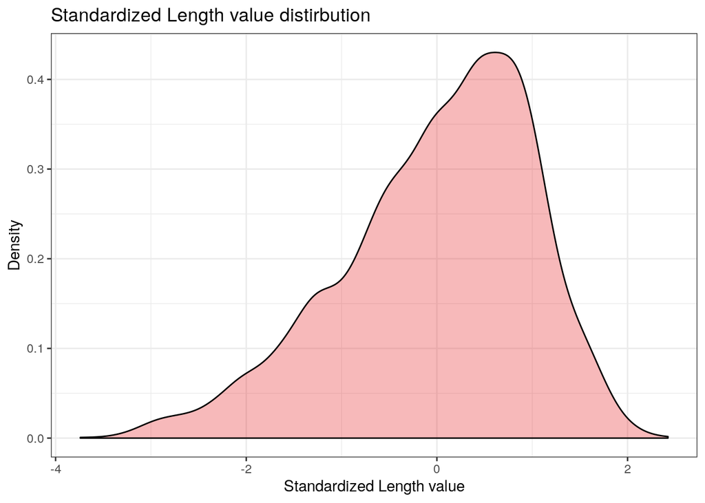

```r
library(ggplot2)
library(RColorBrewer)

ggplot(data,aes(Length_z_scores))+
  geom_density(fill=brewer.pal(n = 3,"Set1")[1],alpha=0.3)+
  xlab("Standardized Length value")+ylab("Density")+
  labs(title = "Standardized Length value distirbution")+
  theme_bw()
```

# Задание 7

**Описание**: Сравни между собой диаметр моллюсков с числом колец 5 и 15. К каким выводам ты пришел? Пожалуйста, оформи результаты так, чтобы мы сразу могли использовать их для статьи.

**Решение**: Посмотрим на распределения диаметров раковин моллюск по группам и проверим на нормальность (Rings = 15 и 5).

```r
library(car)
```

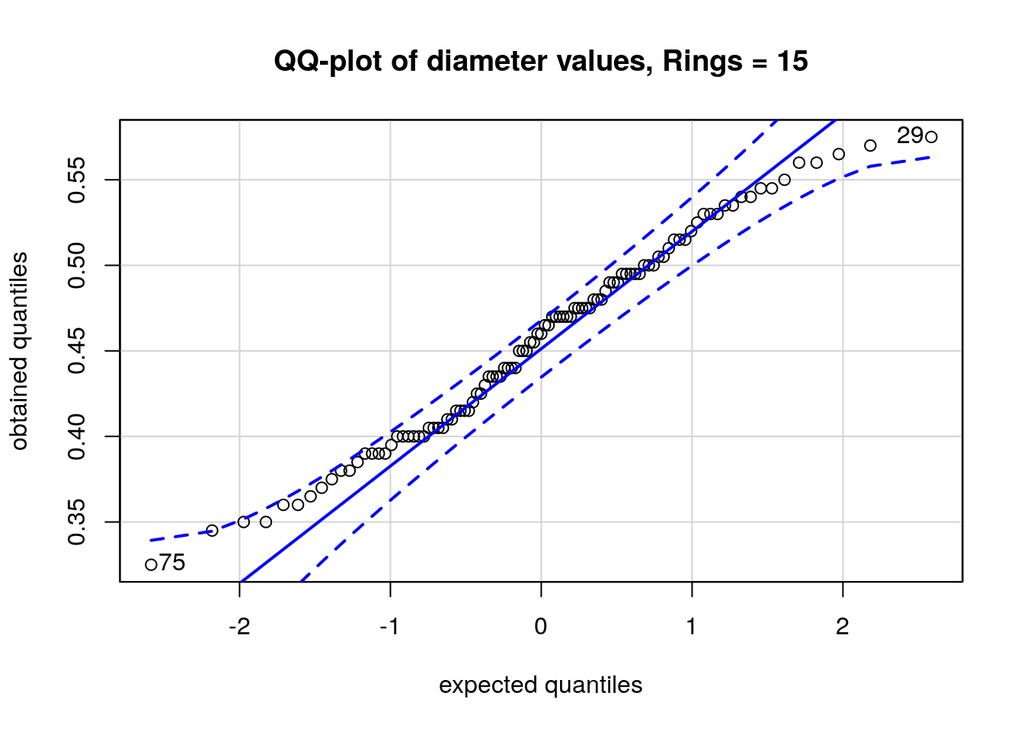

```
## [1] 75 29
```

```r
qqPlot((subset(data,Rings==15))$Diameter,distribution = "norm",
       xlab = "expected quantiles",
       ylab = "obtained quantiles",
       main = "QQ-plot of diameter values, Rings = 15")
```

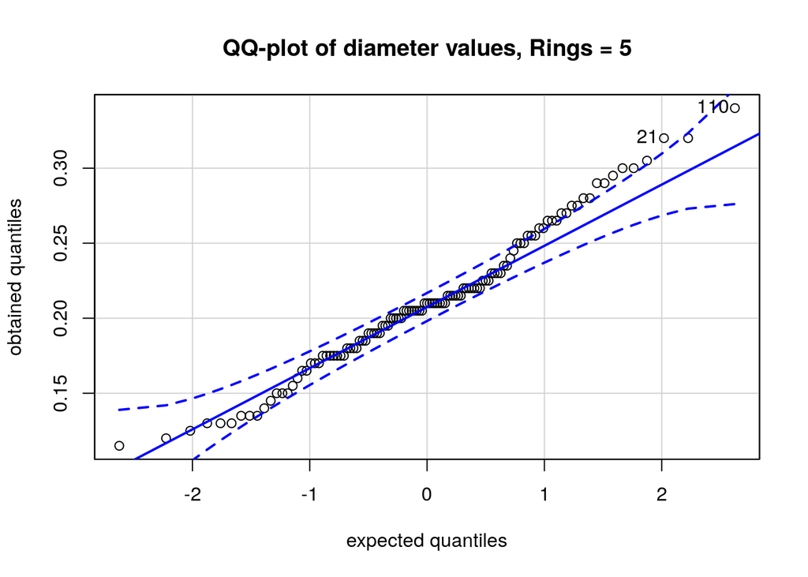

```
## [1] 110  21
```

```r
qqPlot((subset(data,Rings==5))$Diameter,distribution = "norm",
       xlab = "expected quantiles",
       ylab = "obtained quantiles",
       main = "QQ-plot of diameter values, Rings = 5")
```

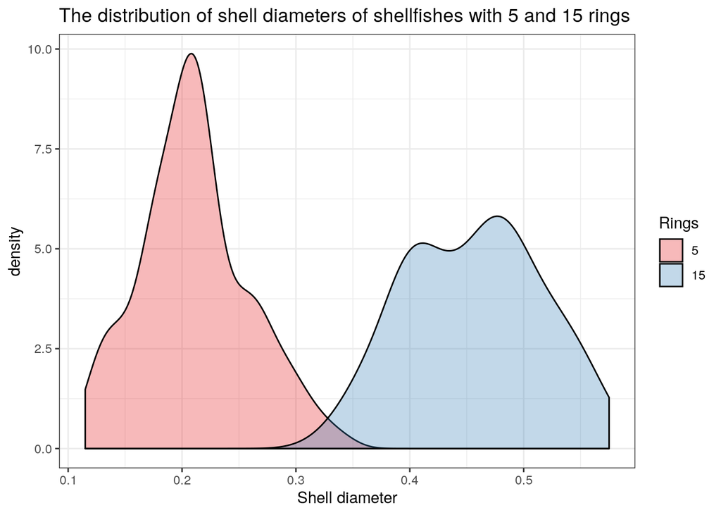

```r
data %>% filter(Rings == 5 | Rings == 15) %>%
  ggplot(.,aes(x=Diameter,fill=as.factor(Rings)))+
  geom_density(alpha=0.3)+
  xlab("Shell diameter")+
  scale_fill_brewer(palette = "Set1")+
  labs(title = "The distribution of shell diameters of shellfishes with 5 and 15 rings",fill="Rings")+
  theme_bw()
```

Видим, что распределения в двух группам близки к нормальному, и распределение диаметров раковин моллюсков с 15 кольцами смещено правее моллюсков с 5 кольцами. Важно отметить, нас достаточно большие выборки. Таким образом мы можем применить t-test, для проверки достоверности отличий между выборками по параметру *Diameter*.

Можем составить нулевую и альтернативные гипотезы: Нулевая - раковины моллюсков с количеством колец 5 и 15 не различаются

Альтернативная - раковины моллюсков (по параметру Diameter) с количеством колец 5 меньше чем у моллюсков с диаметром 15.

```r
t.test_res <- t.test(Diameter ~ Rings, subset(data,Rings==c(5,15)),alternative="less")
t.test_res
```

```
##
##  Welch Two Sample t-test
##
## data:  Diameter by Rings
## t = -23.973, df = 99.175, p-value < 2.2e-16
## alternative hypothesis: true difference in means is less than 0
## 95 percent confidence interval:
##        -Inf -0.2349806
## sample estimates:
##  mean in group 5 mean in group 15
##        0.2092982        0.4617647
```

```r
library(ggpubr)
```

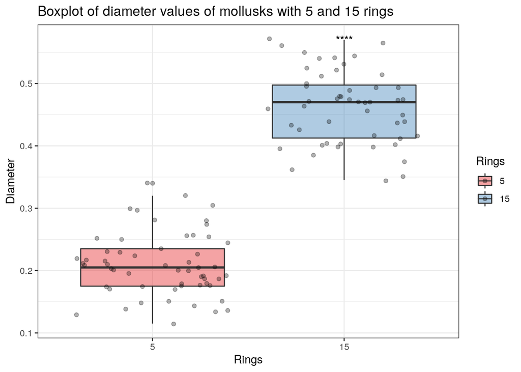

```r
ggplot(subset(data,Rings==c(5,15)), aes(y=Diameter,x=as.factor(Rings),fill=as.factor(Rings)))+
  geom_boxplot(alpha=0.4)+
  geom_jitter(alpha=0.3)+
  scale_fill_brewer(palette = "Set1")+
  xlab("Rings")+
  labs(title="Boxplot of diameter values of mollusks with 5 and 15 rings",fill="Rings")+
  theme_bw()+
  stat_compare_means(method = "t.test",paired = F,label = "p.signif",ref.group = 1)
```

**Вывод**: отвергаем нулевую гипотезу: диаметры раковин моллюсков с 5 кольцами достоверно меньше чем диаметры раковин моллюсков с 15 кольцами $\sf{t_{99.175}=-23.973, p=2.2\cdot10^{-16}}$. Ууказали число степеней свобод (99.175), значение t-критерия (-23.973) а также само значение p-value.

# Задание 8

**Описание**: нас особенно интересуют переменные Diameter и Whole_weight. Что ты можешь про них сказать? Есть ли у нас основания предполагать, что они могут быть взаимосвязаны? Как ты это определил?

**Решение**: необходимо сделать корреляционный анализ, для этого важно понимать, какое распределение у исследуемых переменных. Построим QQ-plot и density plot для каждой их них.

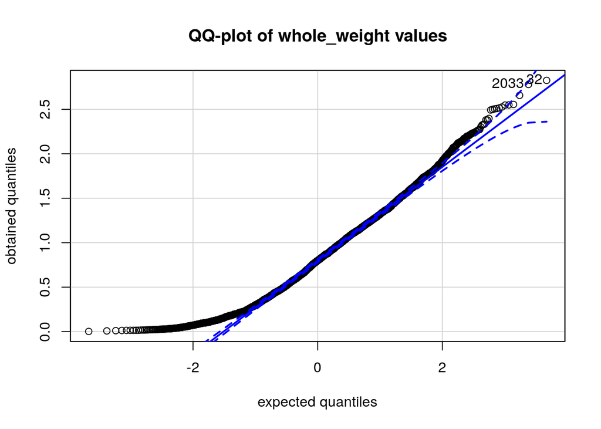

```
## [1]   32 2033
```

```r
qqPlot(data$Whole_weight,distribution = "norm",
       xlab = "expected quantiles",
       ylab = "obtained quantiles",
       main = "QQ-plot of whole_weight values")
```

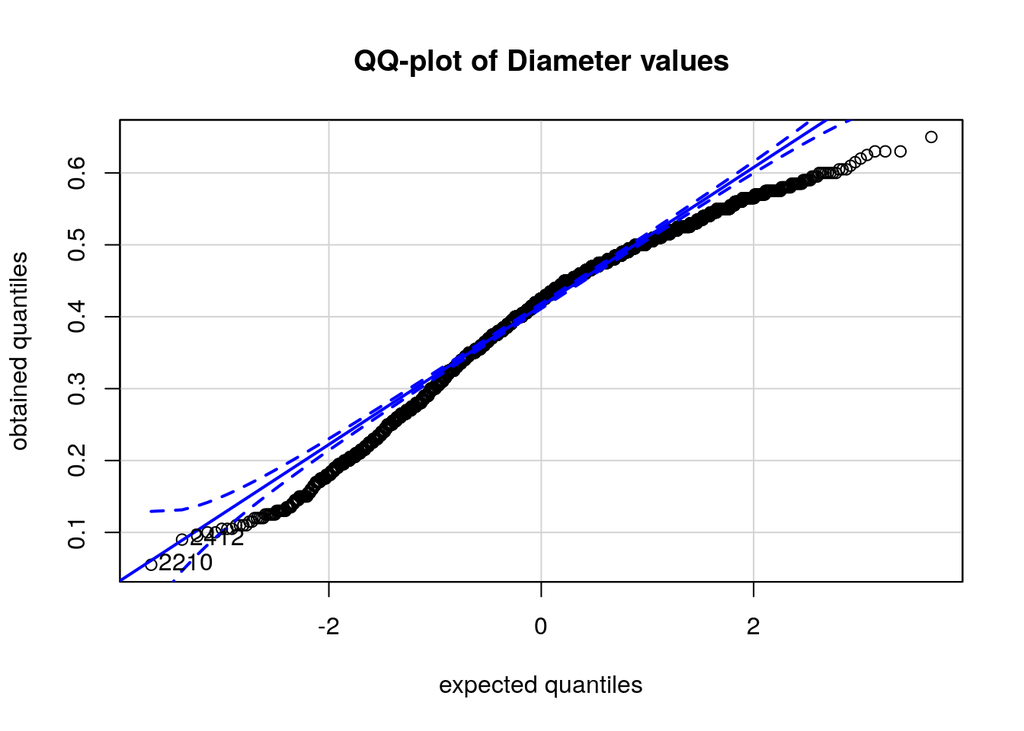

```
## [1] 2210 2412
```

```r
qqPlot(data$Diameter,distribution = "norm",
       xlab = "expected quantiles",
       ylab = "obtained quantiles",
       main = "QQ-plot of Diameter values")
```

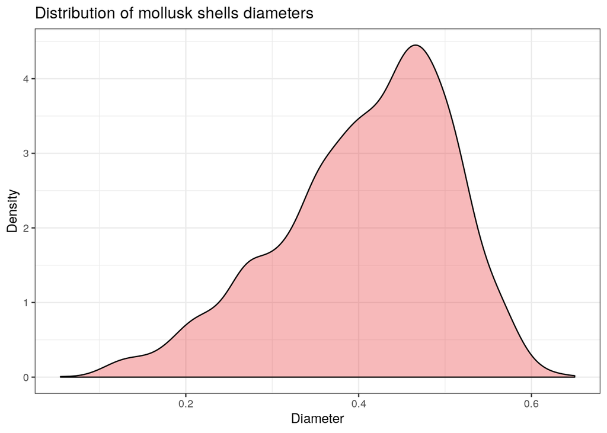

```r
ggplot(data)+
  geom_density(aes(Diameter),fill=brewer.pal(n = 3,"Set1")[1],alpha=0.3)+
  theme_bw()+
  ylab("Density")+
  labs(title = "Distribution of mollusk shells diameters")
```

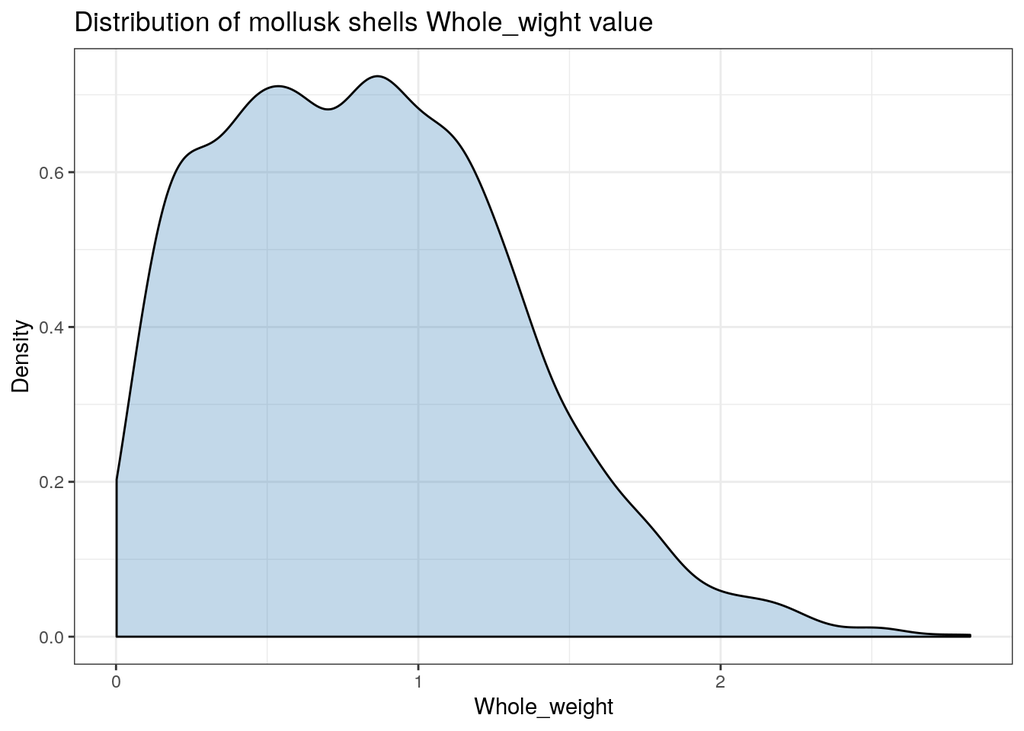

```r
ggplot(data)+
  geom_density(aes(Whole_weight),fill=brewer.pal(n = 3,"Set1")[2],alpha=0.3)+
  theme_bw()+
  ylab("Density")+
  labs(title = "Distribution of mollusk shells Whole_wight value")
```

Видим, что в обоих случаях распределение далеко от нормального, поэтому используем критерий корреляции Спирмена.
$$\rho = 1- {\frac {6 \sum_{i=1}^{n} d_i^2}{n(n^2 - 1)}}$$

```r
cor_result <- cor.test(data$Diameter, data$Whole_weight, method ="spearman")
cor_result
```

```
##
##  Spearman's rank correlation rho
##
## data:  data$Diameter and data$Whole_weight
## S = 356421765, p-value < 2.2e-16
## alternative hypothesis: true rho is not equal to 0
## sample estimates:
##       rho
## 0.9706347
```

**Вывод**: мы видим, что связь между переменная крайне сильная, о чем говорит высокий коэффициент $\rho$ и низкий p value.